# Layout automation with python

## Thomas Ferreira de Lima

### Oct 31st, 2019

# Outline

- Motivation for procedural layout
- Basic definitions
- Installation requirements
  - KLayout
  - Python/Docker
- An overview of Zeropdk
- Using SiEPIC with Zeropdk
  - Demo 1: Using SiEPIC cell library
- Hierarchical layout
  - Demo 2: MZI PCell
- Automated cell transformation
  - Demo 3: Procedural routing
- Advanced layout techniques:
  - Geometry unit testing (lytest)
  - Visual debugging (lyipc)
  - Version control and collaboration
  - Outlook (help needed with DRC, )

# Motivation for procedural layout

- [GDSII](https://www.artwork.com/gdsii/gdsii/) is the industry standard file format for IC layout.
- It organizes geometry in polygons, cells, and cell references.
- However, it is quasi-binary: understood by machines, useless to humans.
- There is no support for parameters, design intent, comments, connectivity, physical data.
- Poor representation of curves

## GDS has problems with curves

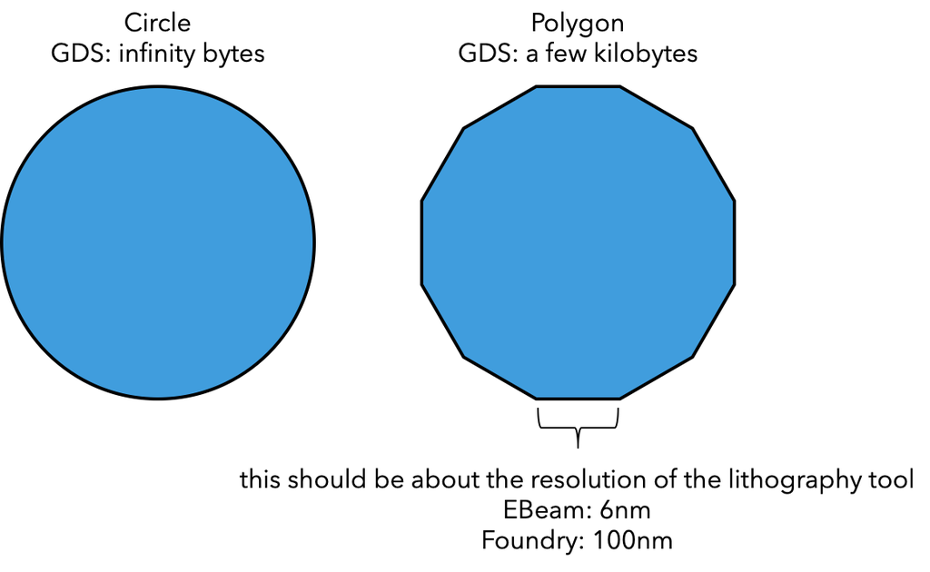

## GDS does not capture logical relation

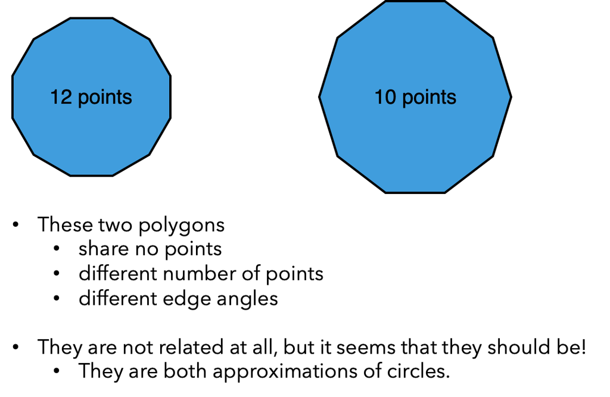

# Basic definitions

## PCells

PCells are the foundation of layouts with more than a couple polygons

- Rule of thumb: one pcell per device
- Defined by code (logic) instead of points (geometry)
- Reused to create many different geometries
- Easy to edit
- Can be nested

## Routing elements

Routing elements refer to the connections between devices (drawn in PCells). They could be metal traces, optical waveguides, or I/O elements.

## Ports

The connection between PCells and routing elements are defined in the concept of *Ports*. The port must contain information on the type of connection, the dimensions of the routing elemenet (e.g. waveguide width), a human-readable name, and positioning.

# Installation Instructions (Simple)

## Docker

I have prepared a docker container with all the necessary packages pre-installed. It is compatible with all OS and runs isolated from your installation.

### 1. Download Docker:

- Mac: https://download.docker.com/mac/stable/Docker.dmg
- Windows: https://download.docker.com/win/stable/Docker%20for%20Windows%20Installer.exe
  - **Note:** on Windows, the installation will require you to **sign out** and sign in, so save all your work!

### 2. Install Docker

The first time you start Docker it will pop up a dialog telling you you need an account. You do **not** need an account. Close the dialog that tells you this: Docker is already running and fully functional. There are [thousands of people](https://github.com/docker/docker.github.io/issues/6910) complaining about the fact that they try to force you to login in order to download/use it.

### 3. Pull docker image from docker.io

Open your command line terminal (cmd in Windows) and type:

```
docker pull felimath/zeropdk
```

You can check the Docker Image with

```
docker images
```

It should show:

```
REPOSITORY                 TAG                 IMAGE ID            CREATED              SIZE
felimath/zeropdk           latest              6d226ecaf854        About a minute ago   1.42GB
...
```

### 4. Navigate to the demo folder, downloaded from github.

Download the demo files from the [workshop's github repo](https://github.com/thomaslima/2019-siepic-workshop-zeropdk) and navigate to the demo folder.

#### Using git:

```
git clone https://github.com/thomaslima/2019-siepic-workshop-zeropdk.git ~/2019-siepic-workshop-zeropdk
```

If you have cloned the repo, navigate to `~/2019-siepic-workshop-zeropdk/demo` with:

```
cd ~/2019-siepic-workshop-zeropdk/demo
```

#### Downloaded zipped file:

If you don't have git (Windows, or any other reason), feel free to download a [zip file directly from github](https://github.com/thomaslima/2019-siepic-workshop-zeropdk/archive/master.zip). In my computer, I extracted to the default location and used the following command to get there:

```
# windows
cd Downloads\2019-siepic-workshop-zeropdk-master\2019-siepic-workshop-zeropdk-master\demo

# bash (unix)
cd ~/Downloads/2019-siepic-workshop-zeropdk-master/demo
```

### 5. Run the jupyter notebook start script.

From within the demo folder, run the following command in your console

```
# windows
start-jupyter-windows.bat
# unix
./start-jupyter-unix.sh
```

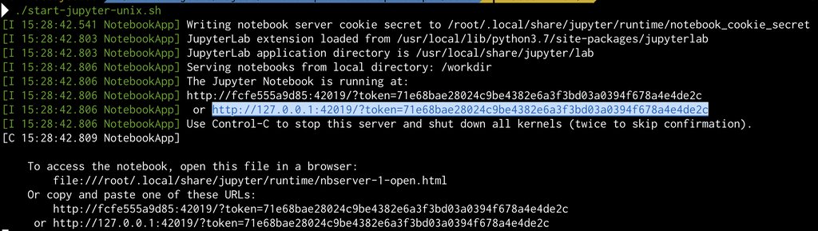

### Final step:

Open a browser and go to the highlighted address as shown above. In my case, it was `http://127.0.0.1:42019/?token=71e68bae28024c9be4382e6a3f3bd03a0394f678a4e4de2c`, but yours will have a different token.

# Installation Instructions (Advanced)

## Python 3

I write all my scripts using python 3.6+ in mind. I did not pay special attention to backwards compatibility with earlier versions. Fixing syntax bugs should be straightforward if you are experienced with python. If you need to use the packages or demos presented here, feel free to submit a pull request to the relevant repositories.

## KLayout

[KLayout](https://www.klayout.de) is an open-source viewer and editor of IC layout files. It has a programming interface with Python and Ruby programming lanaguages. Recently, a pip package was released for the following python distributions:

| OS | Python Version |
| --- | --- |
| macOS 10.11+ | 2.7, 3.7 |
| macOS 10.13+ | 3.5, 3.6 |
| linux x64, x32 | 2.7, 3.5, 3.6, 3.6 |
| win32, win64 | 3.5, 3.6, 3.7 |

*Note for advanced users:* You can attempt to build klayout from source by running `python setup.py install` on the cloned folder from [klayout's github repo](https://github.com/KLayout/klayout).

## Zeropdk

Zeropdk is a python opensource package with basic tools for photonics layout based on the klayout database engine. It is akin to SiEPIC-tools but it was written so that it could be compatible with any foundry's layer stacks. It can also be installed with pip via `pip install zeropdk`. Alternatively, install from source via [the github repo](https://github.com/lightwave-lab/zeropdk). Documentation is scarce at the moment but hopefully this workshop will be a good start.

## Meta: Adapting the docker container to your demo

If you like Docker and want to build your own Docker image (opensource or closed source), I put the recipe (called *Dockerfile*) inside the `docker-image` folder.